```python
import os
from IPython.core.display import Image, display
```

# Deliverable 1:

If we already know the coordinate system, find out how hard it is to align the atlas. Set a specific date when we are confident we will be able to finish the task.

- Estimated time: 3 weeks from when Kwame gets us the tutorials
- Reasoning:
  - 1 week to learn how to properly ingest files
  - 1 week to learn how to ndreg files - ndreg dependencies, installation, tutorials, sample data, etc.
  - 1 week to build pipeline and compute all brains

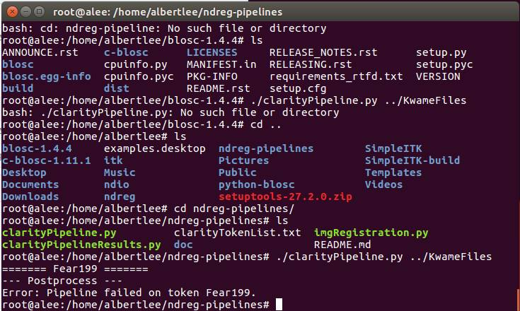

```python
display(Image(filename = '../../AlbertImages/pipelinefail.jpg'))
```

# Deliverable 2:

Ask Ailey for the tokens for the new brains.

- CC'd Jovo.
- Got: Aut1360, Aut1367, Aut1374, AutA

# Deliverable 3/5:

3: Take each level 5 down sampled brain and compute the graph statistics on the 12 (15) brains.  
5: Use Greg’s dataset_variance repo and apply the code.

- https://github.com/NeuroDataDesign/seelviz/blob/gh-pages/Jupyter/Graph%20Statistics%20(PNG%20Outputs).ipynb

# Deliverable 4:

Talk to Kwame about registered brains so we can use atlas coordinates.

- Kwame stated that next week he will have tutorials up that we can use
- Said he would contact us next week for a time

# Deliverable 6:

Practice with AWS micro-instances, specifically learn how to set it up, learn what a micro instance is, find out how to put stuff in the instance. Deliverable will be a screen shot of a running micro-instance with files inside, and cat /proc/meminfo.

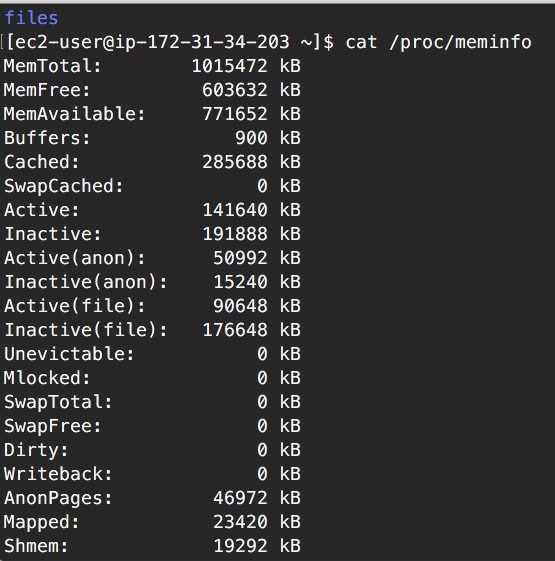

```python
display(Image(filename = '../../AlbertImages/files.png'))
```

# Reach Goal (GraphExplorer):

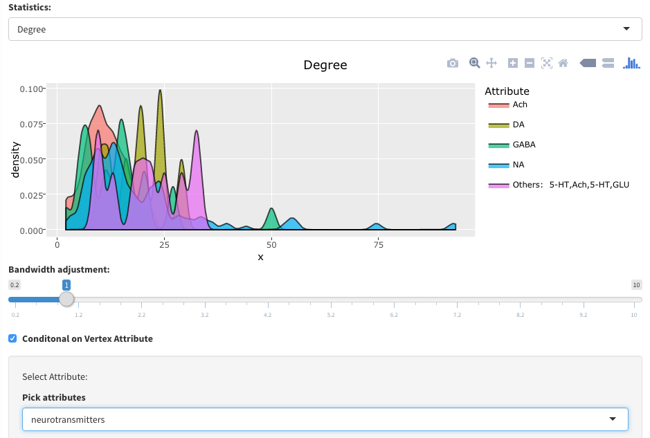

```python
display(Image(filename = '../../AlbertImages/screen1.png'))
```

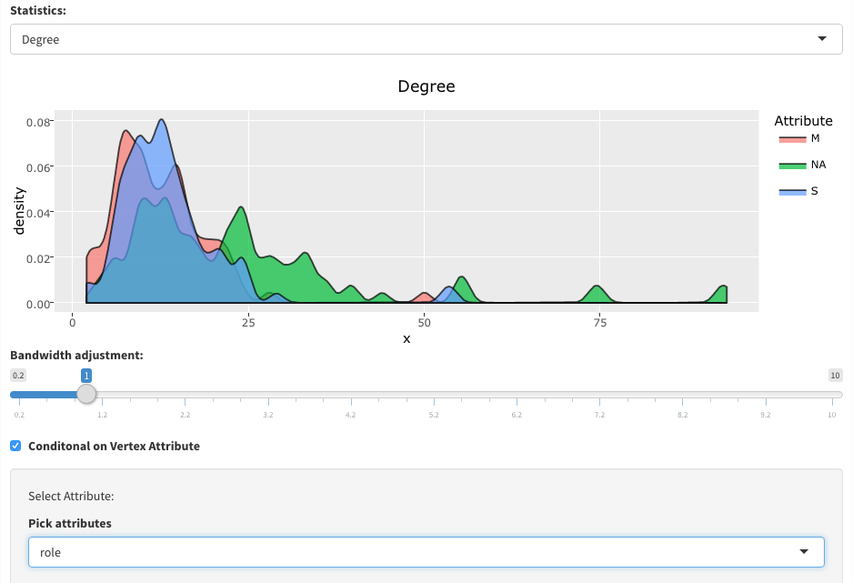

```python
display(Image(filename = '../../AlbertImages/screen2.png'))
```

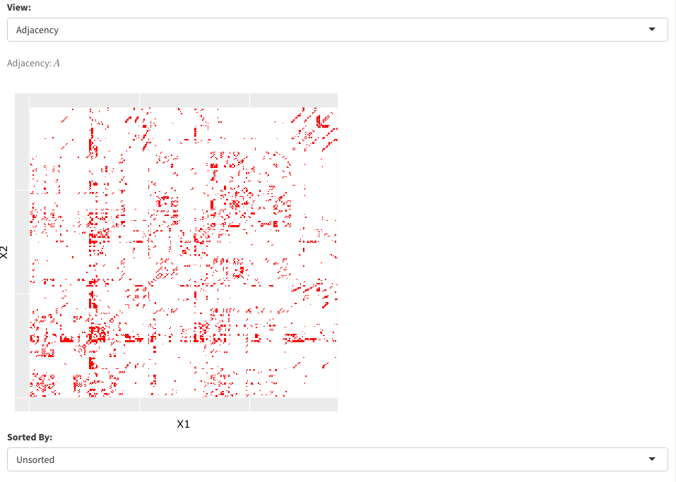

```python
display(Image(filename = '../../AlbertImages/screen3.png'))
```

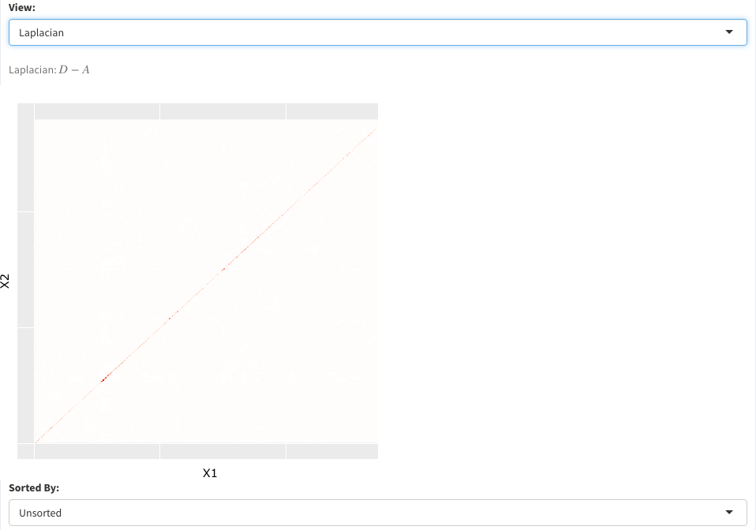

```python
display(Image(filename = '../../AlbertImages/screen4.png'))
```

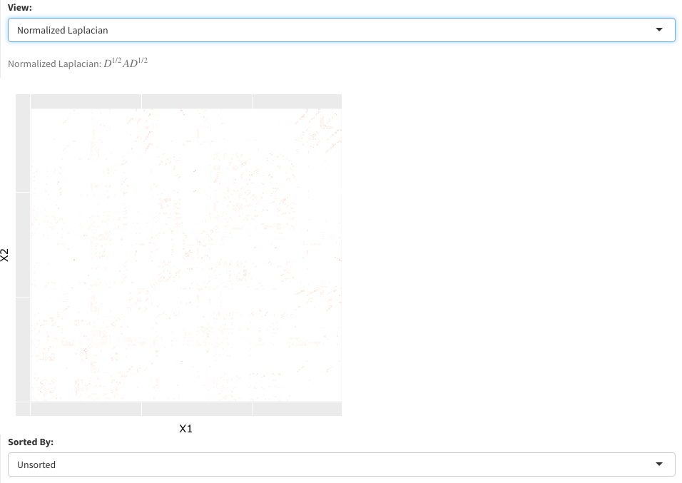

```python
display(Image(filename = '../../AlbertImages/screen5.png'))
```

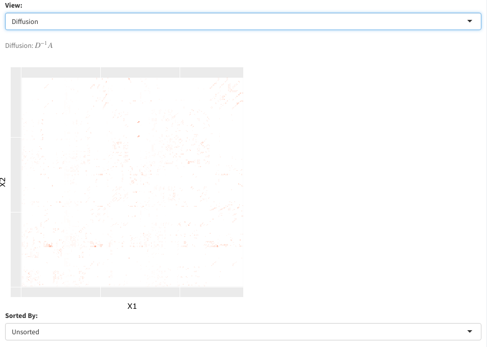

```python
display(Image(filename = '../../AlbertImages/screen6.png'))
```

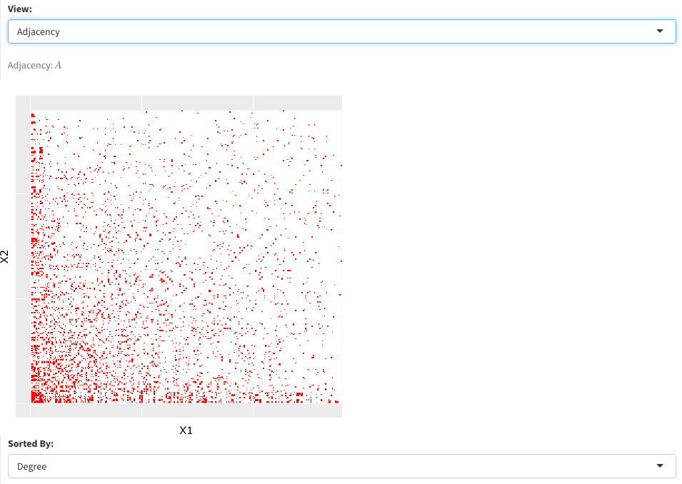

```python
display(Image(filename = '../../AlbertImages/screen7.png'))
```

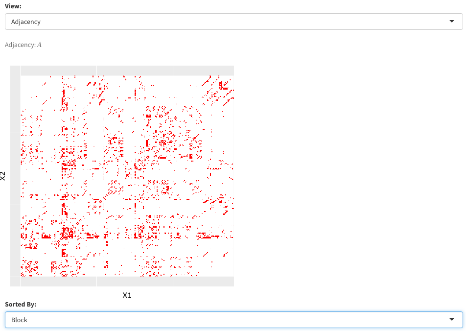

```python
# Header 1
display(Image(filename = '../../AlbertImages/screen8.png'))
```

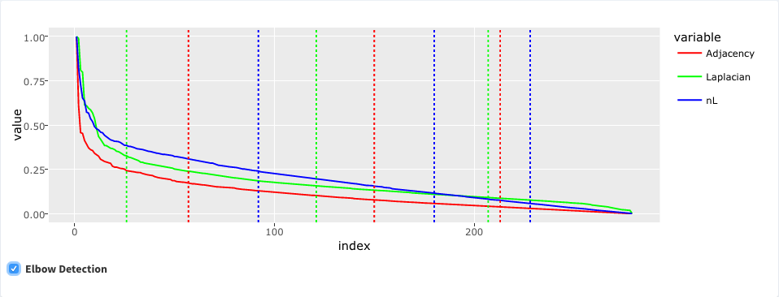

```python
display(Image(filename = '../../AlbertImages/screen10.png'))
```

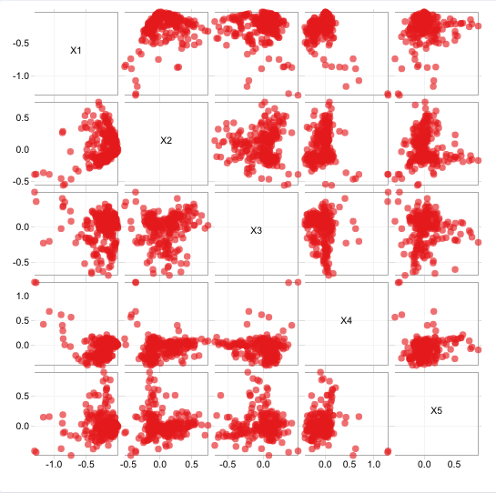

```python
display(Image(filename = '../../AlbertImages/screen11.png'))
```

# Reach Goal (New Image Processing):

[figure not shown]

```python
display(Image(filename = '../../AlbertImages/screen12.png'))
```

[figure not shown]

```python
display(Image(filename = '../../AlbertImages/screen13.png'))
```

[figure not shown]

```python
display(Image(filename = '../../AlbertImages/screen14.png'))
```

# Reach Goal (Accessibility):

- https://neurodatadesign.github.io/seelviz/nojohns/clarity.m.html